# R Notebook

```r
library(tidyverse)
library(janitor)
library(skimr)
```

# defining a ‘mode’ function

```r
get_mode <- function(data){
  tabled_data <- table(data)
  table_names <- names(tabled_data)
  return( table_names[tabled_data == max(tabled_data)] )
}
```

```r
mobile_data <- read_csv("data/20190928-items.csv") %>%
clean_names()
```

#explore dataset

```r
nrow(mobile_data)
```

```
[1] 792
```

```r
ncol(mobile_data)
```

```
[1] 9
```

```r
skim(mobile_data)
```

```
── Data Summary ────────────────────────
                           Values
Name                       mobile_data
Number of rows             792
Number of columns          9
_______________________
Column type frequency:
  character                7
  numeric                  2
________________________
Group variables            None
```

|  | skim_variable | n_missing | complete_rate | min | max | empty | n_unique | whitespace |
| --- | --- | --- | --- | --- | --- | --- | --- | --- |
| 1 | asin | 0 | 1.0000000 | 10 | 10 | 0 | 792 | 0 |
| 2 | brand | 0 | 1.0000000 | 4 | 8 | 0 | 10 | 0 |
| 3 | title | 0 | 1.0000000 | 19 | 200 | 0 | 785 | 0 |
| 4 | url | 0 | 1.0000000 | 60 | 97 | 0 | 792 | 0 |
| 5 | image | 0 | 1.0000000 | 87 | 87 | 0 | 719 | 0 |
| 6 | review_url | 0 | 1.0000000 | 49 | 49 | 0 | 792 | 0 |
| 7 | prices | 215 | 0.7285354 | 6 | 19 | 0 | 447 | 0 |

|  | skim_variable | n_missing | complete_rate | mean | sd | p0 | p25 | p50 | p75 | p100 | hist |
| --- | --- | --- | --- | --- | --- | --- | --- | --- | --- | --- | --- |
| 1 | rating | 0 | 1 | 3.607576 | 0.6687295 | 1 | 3.2 | 3.7 | 4.00 | 5 | ▁▁▅▇▂ |
| 2 | total_reviews | 0 | 1 | 104.231061 | 166.2425030 | 1 | 7.0 | 31.5 | 122.25 | 984 | ▇▁▁▁▁ |

#Q2 find the brand with the highest number of phones in this dataset

# do this by arranging count of brand by order

```r
mobile_data %>%
  group_by(brand) %>%
  summarise(count_brand = n()) %>%
  arrange(desc(count_brand)) %>%
  head(10)
```

| brand | count_brand |
| --- | --- |
| Samsung | 397 |
| Apple | 101 |
| Motorola | 100 |
| Nokia | 49 |
| HUAWEI | 36 |
| Google | 33 |
| Sony | 29 |
| Xiaomi | 27 |
| ASUS | 13 |
| OnePlus | 7 |

#do this by looking at the distribution

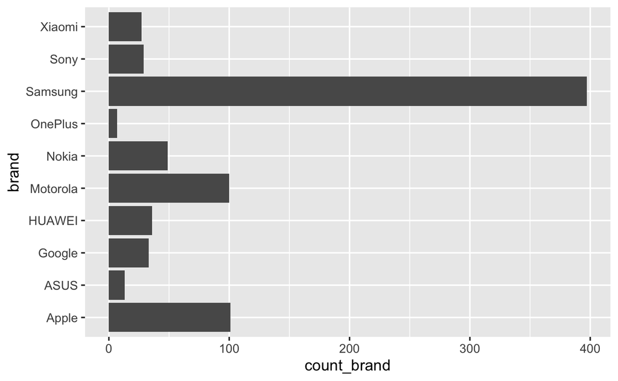

```r
mobile_data %>%
  group_by(brand) %>%
  summarise(count_brand = n()) %>%
  ggplot(aes(x= brand, y = count_brand)) +
  geom_col() +
  coord_flip()
```

# do this using the mode function

```r
top_brand <- mobile_data %>%
  summarise(mode = get_mode(brand)) %>%
  pull()
```

# Q3 For your top brand, plot the distribution of phone ratings as a probability density, overlaying a fitted normal distribution. Do you think the normal distribution provides a good model of these ratings?

```r
stats_top_brand <- mobile_data %>%
  filter(brand == top_brand) %>%
  select(rating) %>%
  summarise(r_mean = mean(rating),
            r_sd = sd(rating),
            r_max = max(rating),
            r_min = min(rating))
```

#what would a normal distribution look like?

```r
  #create a sequence covering range of the data
  x=seq(from = stats_top_brand$r_min,
        to = stats_top_brand$r_max,
        by = (stats_top_brand$r_max-stats_top_brand$r_min)/20
        )
 #create a normal distribution over this set of values using mean and sd from dataset
 f1_x = dnorm(x = x, mean = stats_top_brand$r_mean, sd = stats_top_brand$r_sd)
```

# put this data in a tibble to use later

```r
freq_dist <- tibble(
    x = x,
    f1_x = f1_x
  )
```

#plot this

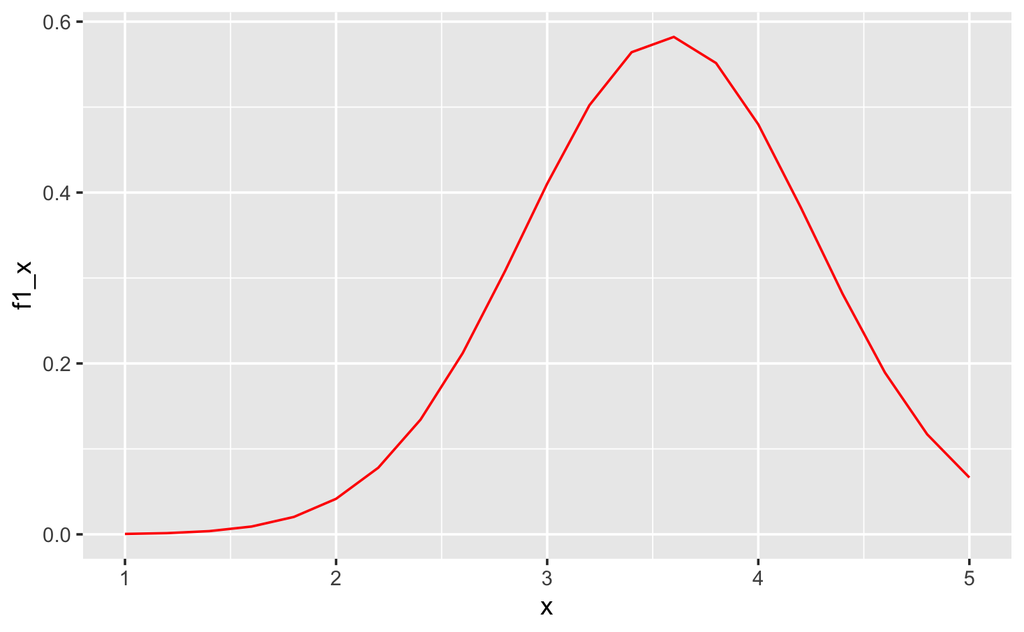

```r
 ggplot()+
    aes(x = x, y = f1_x) +
 geom_line(col = "red")
```

```r
 #geom_line(aes(x = x, y = f1_x),col = "red")
```

#plot a basic histogram. This is a frequency distribution

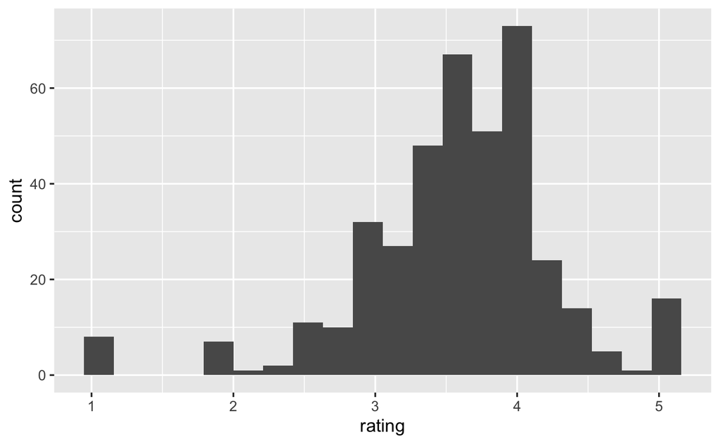

```r
mobile_data %>%
  filter(brand == top_brand) %>%
  select(rating) %>%
  ggplot(aes(x=rating)) +
  geom_histogram(bins = 20)
```

#plot as a density plot using geom_density

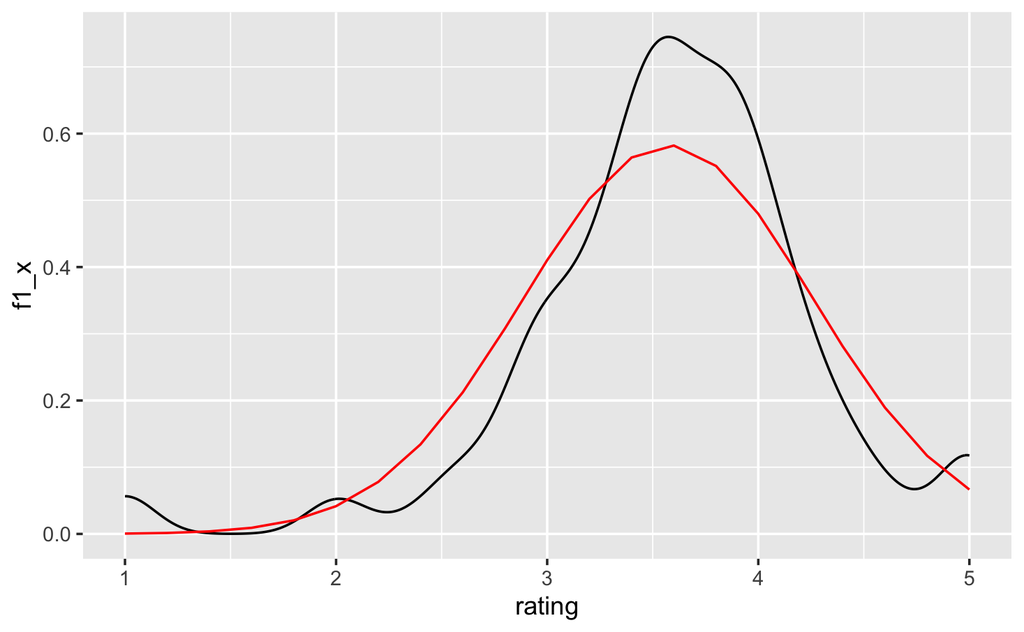

```r
mobile_data %>%
  filter(brand == top_brand) %>%
  select(rating) %>%
  ggplot() +
  geom_density(aes(x=rating)) +
  #overlay this with the freq distribution we calculated earlier
  geom_line(data = freq_dist, aes(x = x, y = f1_x),col = "red")
```

These two distributions look similar (ish). The data is more peaky than a normal distribution. Less spread than a normal distribution or variance about the mean is lower? Not sure how do we quanitfy the similarness?

#Q4 We can be more quantitative in comparing the distribution of top brand ratings with a normal distribution. You calculated the mean() and sd() of your distribution in an earlier question. Use these values to calculate the proportions of ratings within one-, two- and three standard deviations of the mean. Compare these proportions with those you expect for a normal distribution.

```r
within_1sd <- mobile_data %>%
  filter(brand == top_brand) %>%
  #first normalise ratings
  mutate(norm_ratings = (rating-stats_top_brand$r_mean)/stats_top_brand$r_sd) %>%
  #then filter
  filter(between(norm_ratings, left = -1, right = 1)) %>%
  summarise(count = n()/ sum(mobile_data$brand == top_brand))
```

```r
within_2sd <- mobile_data %>%
  filter(brand == top_brand) %>%
  #first normalise ratings
  mutate(norm_ratings = (rating-stats_top_brand$r_mean)/stats_top_brand$r_sd) %>%
  #then filter
  filter(between(norm_ratings, left = -2, right = 2)) %>%
  summarise(count = n()/ sum(mobile_data$brand == top_brand))
```

```r
within_3sd <- mobile_data %>%
  filter(brand == top_brand) %>%
  #first normalise ratings
  mutate(norm_ratings = (rating-stats_top_brand$r_mean)/stats_top_brand$r_sd) %>%
  #then filter
  filter(between(norm_ratings, left = -3, right = 3)) %>%
  summarise(count = n()/ sum(mobile_data$brand == top_brand))
```

[output not shown]

```r
within_1sd

pnorm(q=1)-pnorm(q=-1)
```

```
[1] 0.6826895
```

#Q5 Investigate the use of the qqnorm() plot in R to determine whether data is normally distributed. What is a ‘quantile-quantile plot’? What do we expect to see in a qqnorm() plot if data is nearly normally distributed?

```r
mobile_data %>%
  filter(brand == top_brand) %>%
  select(rating) %>%
  qqnorm(rating, )
```

[output not shown]

```r
 f1_x = pnorm(x = x, mean = 3, sd = 2)
```

```
Error in pnorm(x = x, mean = 3, sd = 2) : unused argument (x = x)
```

qqnorm(f1_x)

[output not shown]